# ggplot2 Themes: Fundamentals, Structure & Custom Creation

## 6.2 Creating Theme Variants

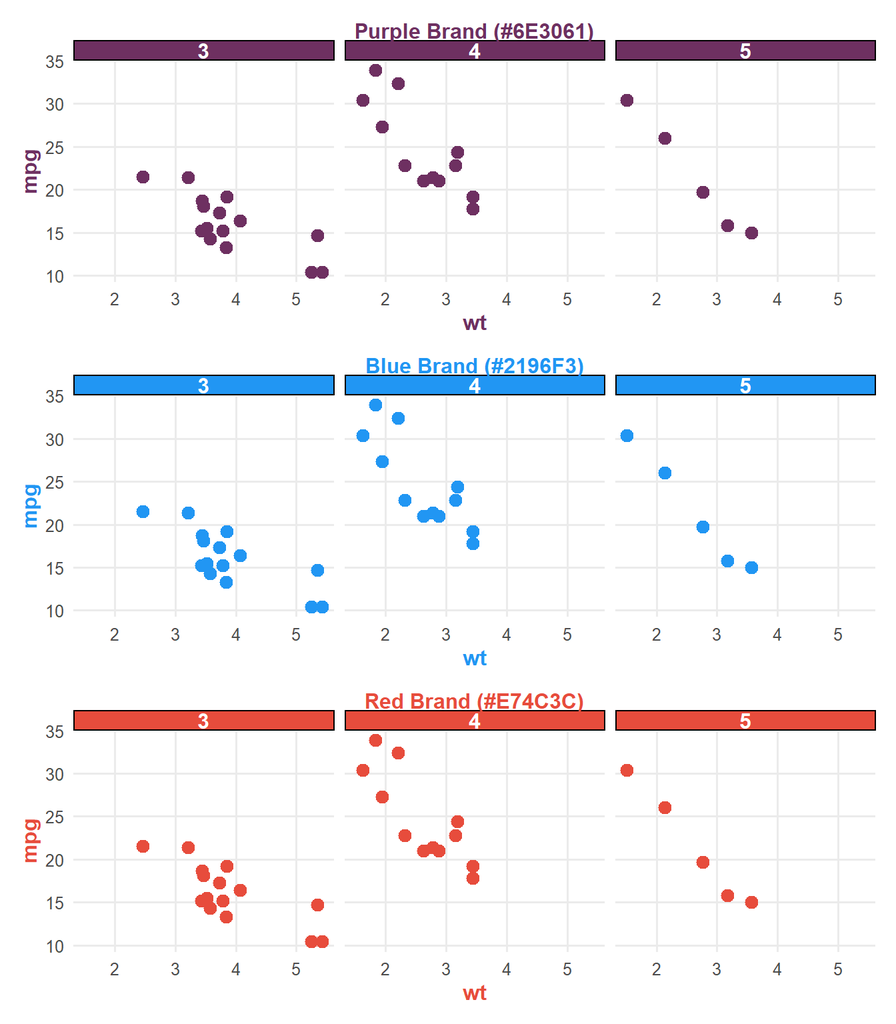

```r
# Base theme with parameterized color
theme_branded <- function(base_size = 12, brand_color = "#6E3061") {
  theme_minimal(base_size = base_size) %+replace%
    theme(
      panel.grid.minor = element_blank(),
      axis.title = element_text(colour = brand_color, face = "bold"),
      plot.title = element_text(colour = brand_color, face = "bold", hjust = 0.5),
      strip.background = element_rect(fill = brand_color),
      strip.text = element_text(colour = "white", face = "bold")
    )
}

# Create variants with different brand colors
p_purple <- ggplot(mtcars, aes(wt, mpg)) +
  geom_point(colour = "#6E3061", size = 3) +
  facet_wrap(~ gear) +
  theme_branded(brand_color = "#6E3061") +
  labs(title = "Purple Brand (#6E3061)")

p_blue <- ggplot(mtcars, aes(wt, mpg)) +
  geom_point(colour = "#2196F3", size = 3) +
  facet_wrap(~ gear) +
  theme_branded(brand_color = "#2196F3") +
  labs(title = "Blue Brand (#2196F3)")

p_red <- ggplot(mtcars, aes(wt, mpg)) +
  geom_point(colour = "#E74C3C", size = 3) +
  facet_wrap(~ gear) +
  theme_branded(brand_color = "#E74C3C") +
  labs(title = "Red Brand (#E74C3C)")

# Display variants
p_purple / p_blue / p_red
```

# 7 Advanced Techniques

## 7.1 Responsive Theme with Scaling

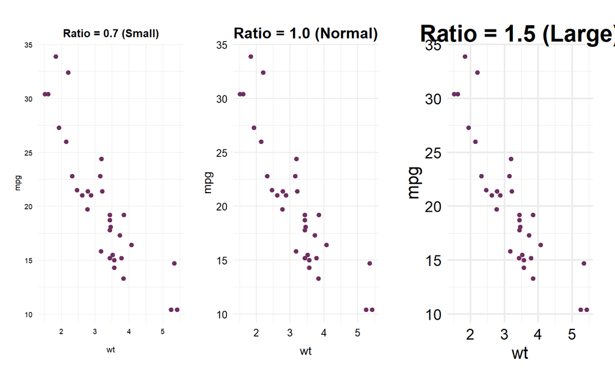

```r
theme_responsive <- function(base_size = 12, ratio = 1) {
  theme_minimal(base_size = base_size) %+replace%
    theme(
      # Scale elements based on ratio parameter
      axis.text = element_text(size = base_size * ratio * 0.8),
      axis.title = element_text(size = base_size * ratio * 0.9),
      plot.title = element_text(size = base_size * ratio * 1.2, face = "bold"),
      panel.grid.major = element_line(linewidth = 0.5 * ratio),
      plot.margin = margin(
        t = 10 * ratio,
        r = 10 * ratio,
        b = 10 * ratio,
        l = 10 * ratio
      )
    )
}

# Compare different scales
p_small <- ggplot(mtcars, aes(wt, mpg)) +
  geom_point(colour = "#6E3061") +
  theme_responsive(ratio = 0.7) +
  labs(title = "Ratio = 0.7 (Small)")

p_normal <- ggplot(mtcars, aes(wt, mpg)) +
  geom_point(colour = "#6E3061") +
  theme_responsive(ratio = 1.0) +
  labs(title = "Ratio = 1.0 (Normal)")

p_large <- ggplot(mtcars, aes(wt, mpg)) +
  geom_point(colour = "#6E3061") +
  theme_responsive(ratio = 1.5) +
  labs(title = "Ratio = 1.5 (Large)")

p_small + p_normal + p_large
```

## 7.2 Conditional Theme Elements

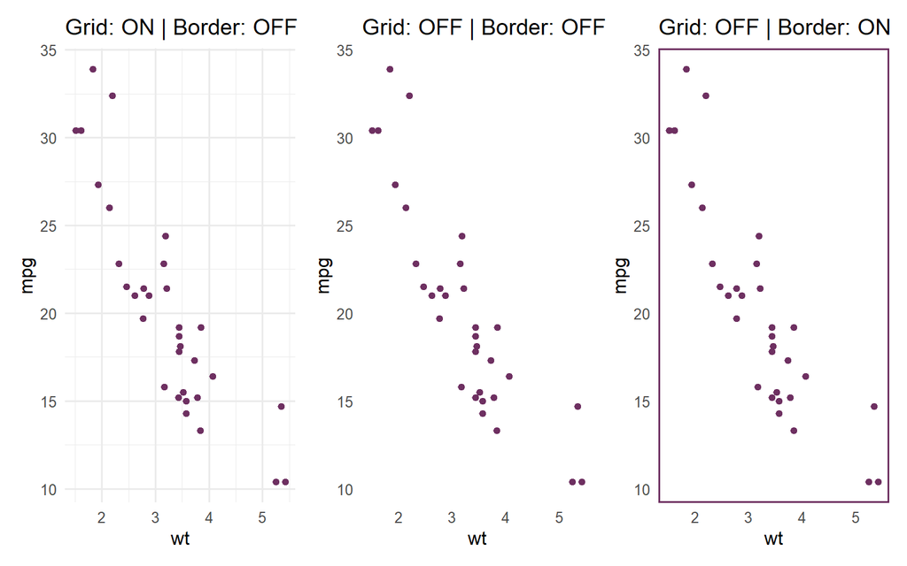

```r
theme_conditional <- function(base_size = 12, show_grid = TRUE, show_border = FALSE) {
  t <- theme_minimal(base_size = base_size)

  if (!show_grid) {
    t <- t %+replace% theme(
      panel.grid.major = element_blank(),
      panel.grid.minor = element_blank()
    )
  }

  if (show_border) {
    t <- t %+replace% theme(
      panel.border = element_rect(fill = NA, colour = "#6E3061", linewidth = 1)
    )
  }

  return(t)
}

# Demonstrate conditional themes
p1 <- ggplot(mtcars, aes(wt, mpg)) +
  geom_point(colour = "#6E3061") +
  theme_conditional(show_grid = TRUE, show_border = FALSE) +
  labs(title = "Grid: ON | Border: OFF")

p2 <- ggplot(mtcars, aes(wt, mpg)) +
  geom_point(colour = "#6E3061") +
  theme_conditional(show_grid = FALSE, show_border = FALSE) +
  labs(title = "Grid: OFF | Border: OFF")

p3 <- ggplot(mtcars, aes(wt, mpg)) +
  geom_point(colour = "#6E3061") +
  theme_conditional(show_grid = FALSE, show_border = TRUE) +
  labs(title = "Grid: OFF | Border: ON")

p1 + p2 + p3
```

## 7.3 Global Theme Settings

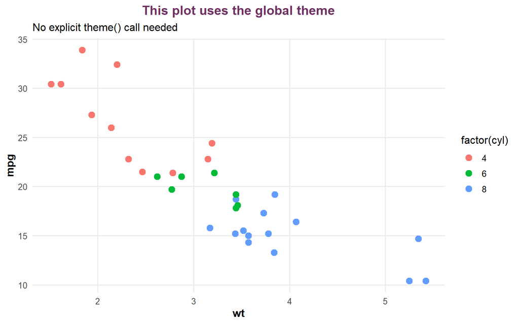

```r
# Save the current theme
old_theme <- theme_get()

# Set a custom theme globally
theme_set(
  theme_minimal(base_size = 12) +
    theme(
      panel.grid.minor = element_blank(),
      plot.title = element_text(face = "bold", colour = "#6E3061", hjust = 0.5),
      axis.title = element_text(face = "bold")
    )
)

# All subsequent plots will use this theme
p_global <- ggplot(mtcars, aes(wt, mpg, colour = factor(cyl))) +
  geom_point(size = 3) +
  labs(
    title = "This plot uses the global theme",
    subtitle = "No explicit theme() call needed"
  )

print(p_global)
```

```r
# Restore the original theme
theme_set(old_theme)
```

**Caution:** `theme_set()` affects all subsequent plots in the R session. Always restore the original theme or use it in a controlled environment like a dedicated script.

## 7.4 Debugging and Testing Themes

```r
# Create a theme for testing
my_test_theme <- theme_custom(base_size = 12)

# 1. Inspect individual elements
cat("Panel grid major setting:\n")
```

```
Panel grid major setting:
```

```r
print(my_test_theme$panel.grid.major)
```

```
<ggplot2::element_line>
 @ colour       : chr "grey85"
 @ linewidth    : num 0.3
 @ linetype     : chr "dashed"
 @ lineend      : NULL
 @ linejoin     : NULL
 @ arrow        : logi FALSE
 @ arrow.fill   : chr "grey85"
 @ inherit.blank: logi FALSE
```

```r
cat("\nPlot title setting:\n")
```

```
Plot title setting:
```

```r
print(my_test_theme$plot.title)
```

```
<ggplot2::element_text>
 @ family       : NULL
 @ face         : chr "bold"
 @ italic       : chr NA
 @ fontweight   : num NA
 @ fontwidth    : num NA
 @ colour       : chr "#6E3061"
 @ size         : 'rel' num 1.4
 @ hjust        : num 0.5
 @ vjust        : NULL
 @ angle        : NULL
 @ lineheight   : NULL
 @ margin       : <ggplot2::margin> num [1:4] 0 0 10 0
 @ debug        : NULL
 @ inherit.blank: logi FALSE
```

```r
# 2. Use calc_element() for computed values
cat("\nComputed panel background:\n")
```

```
Computed panel background:
```

```r
print(calc_element("panel.background", my_test_theme))
```

```
<ggplot2::element_rect>
 @ fill         : chr "grey95"
 @ colour       : logi NA
 @ linewidth    : num 0.545
 @ linetype     : num 1
 @ linejoin     : chr "round"
 @ inherit.blank: logi FALSE
```

```r
# 3. Check for missing elements compared to a complete theme
missing_elements <- setdiff(names(theme_grey()), names(my_test_theme))
if (length(missing_elements) > 0) {
  cat("\nMissing elements compared to theme_grey():\n")
  print(missing_elements)
} else {
  cat("\nNo missing elements found!\n")
}
```

```
No missing elements found!
```

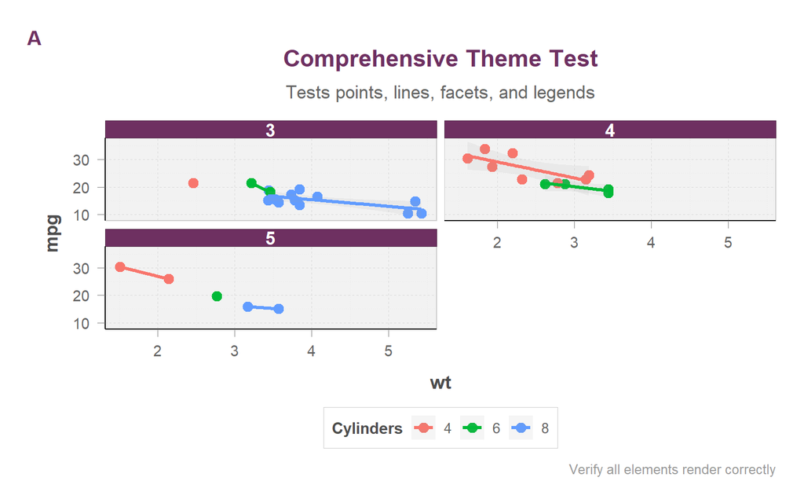

```r
# 4. Create a comprehensive test plot
test_all_features <- ggplot(mtcars, aes(wt, mpg, colour = factor(cyl))) +
  geom_point(size = 3) +
  geom_smooth(method = "lm", se = TRUE, alpha = 0.1) +
  facet_wrap(~ gear, nrow = 2) +
  my_test_theme +
  labs(
    title = "Comprehensive Theme Test",
    subtitle = "Tests points, lines, facets, and legends",
    caption = "Verify all elements render correctly",
    colour = "Cylinders",
    tag = "A"
  )

print(test_all_features)
```

# 8 Best Practices Summary

```r
#' Custom ggplot2 theme - Best Practice Example
#'
#' @param base_size Base font size in points (default: 12)
#' @param base_family Base font family (default: "")
#' @param accent_color Primary accent color for titles and highlights
#'
#' @return A complete ggplot2 theme object
#' @export
#'
#' @examples
#' library(ggplot2)
#' ggplot(mtcars, aes(wt, mpg)) +
#'   geom_point() +
#'   theme_best_practice(accent_color = "#6E3061")
theme_best_practice <- function(base_size = 12,
                                 base_family = "",
                                 accent_color = "#6E3061") {

  # Validate font availability
  if (base_family != "") {
    available_fonts <- systemfonts::system_fonts()$family
    if (!base_family %in% available_fonts) {
      warning("Font family '", base_family, "' not found. Using system default.")
      base_family <- ""
    }
  }

  # Build the theme
  theme_minimal(base_size = base_size, base_family = base_family) %+replace%
    theme(
      # Use rel() for scalable sizes
      plot.title = element_text(
        size = rel(1.3),
        face = "bold",
        colour = accent_color
      ),
      axis.title = element_text(size = rel(1.1)),
      axis.text = element_text(size = rel(0.9)),
      # ... (remaining theme elements)
    )
}
```

**Final Checklist for Production Themes:**

- ✅ Always provide `base_size` and `base_family` parameters
- ✅ Use `rel()` for scalable font sizes
- ✅ Handle missing fonts gracefully
- ✅ Test with scatter, bar, facet, and multi-legend plots
- ✅ Include complete Roxygen documentation
- ✅ Verify WCAG 2.1 AA color contrast ratios
- ✅ Test on both screen and print output

[session information not shown]

This R Markdown document provides:

**Complete structure:**

- YAML header with table of contents, code folding, and syntax highlighting
- Organized into clear sections matching the original flash card content
- Embedded CSS for professional lecture note formatting

**Working examples throughout:**

- Every concept demonstrated with executable R code
- Side-by-side plot comparisons using `patchwork`
- Step-by-step theme building from skeleton to complete theme
- Three complete theme examples (Publication, Dashboard, Dark)

**Visual design:**

- Purple `#6E3061` accent color consistent with the original
- Custom styled callout boxes (note, tip, warning)
- Formatted tables for parameter references
- Clean code blocks with syntax highlighting

**Key features:** - Floating table of contents - Numbered sections - Collapsible code blocks - Professional figure formatting - Complete session information at the end